# Final

```python
import rdata
import pandas as pd
import matplotlib.pyplot as plt
import seaborn as sns
from sklearn.cluster import KMeans
from sklearn.preprocessing import StandardScaler
```

```python
# --- 1. CARGAR LOS DATOS CON RDATA ---
# Parsear y convertir el archivo RData
parsed = rdata.parser.parse_file('listings.RData')
converted = rdata.conversion.convert(parsed)
```

```python
df = converted['listings'] # Aquí es donde se define 'df'
print(df.columns.tolist())
```

```
[np.str_('id'), np.str_('listing_url'), np.str_('scrape_id'), np.str_('last_scraped'), np.str_('source'), np.str_('name'), np.str_('description'), np.str_('neighborhood_overview'), np.str_('picture_url'), np.str_('host_id'), np.str_('host_url'), np.str_('host_name'), np.str_('host_since'), np.str_('…
```

```python
# Limpiar la columna price
df['price'] = df['price'].str.replace('$', '', regex=False)
df['price'] = df['price'].str.replace(',', '', regex=False)

# Convertir a número
df['price'] = pd.to_numeric(df['price'], errors='coerce')

# Ahora sí volvemos a generar num_vars (incluyendo el precio ya corregido)
num_vars = df.select_dtypes(include=['float64', 'int64', 'float32', 'int32']).dropna()
```

```python
print(df['price'].head())
print(df['price'].describe())
print("Cantidad de NaN:", df['price'].isna().sum())
```

```
1     97.0
2    160.0
3     38.0
4    145.0
5     58.0
Name: price, dtype: float64
count    76246.000000
mean       750.509220
std       4250.606945
min          8.000000
25%        120.000000
50%        193.000000
75%        326.000000
max      50123.000000
Name: price, dtype: float64
Cantidad de NaN: 95502
```

```python
print("Objetos en el RData:", converted.keys())
# Asignar el dataframe

# Ver estructura para tu diccionario de variables
print("\n--- Información del Dataset ---")
df.info()
```

```
Objetos en el RData: dict_keys(['listings'])

--- Información del Dataset ---
<class 'pandas.core.frame.DataFrame'>
RangeIndex: 171748 entries, 1 to 171748
Data columns (total 80 columns):
 #   Column                                        Non-Null Count   Dtype
---  ------                                        --------------   -----
 0   id                                            171748 non-null  float64
 1   listing_url                                   171748 non-null  string
 2   scrape_id                                     171748 non-null  float64
 3   last_scraped                                  171748 non-null  string
 4   source                                        171748 non-null  string
 5   name                                          171748 non-null  string
 6   description                                   171748 non-null  string
```

[output cut: 75 more lines]

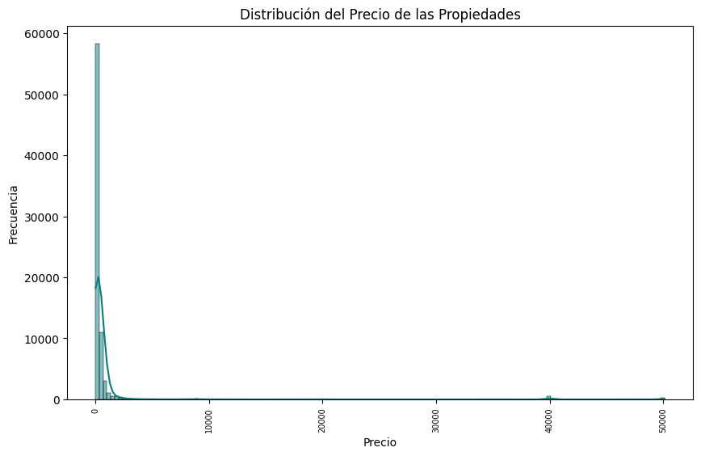

```python
# --- 2. ANÁLISIS EXPLORATORIO: Distribución del precio ---
plt.figure(figsize=(10, 6))
sns.histplot(df['price'].dropna(), bins=150, kde=True, color='teal')
plt.title('Distribución del Precio de las Propiedades')
plt.xlabel('Precio')
plt.xticks(rotation=90,fontsize=7)
plt.ylabel('Frecuencia')
plt.show()
```

La distribución del precio de las propiedades presenta una clara asimetría positiva (sesgo hacia la derecha). Esto indica que la gran mayoría de las viviendas de SmartStay Advisors se concentran en un rango de precios bajos a moderados. Sin embargo, la larga cola hacia la derecha revela la presencia de valores atípicos (outliers); es decir, un grupo reducido de propiedades de lujo o con alta capacidad que tienen precios significativamente más altos que el resto.

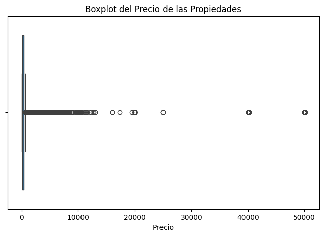

```python
plt.figure(figsize=(8,5))
sns.boxplot(x=df['price'])
plt.title('Boxplot del Precio de las Propiedades')
plt.xlabel('Precio')
plt.show()
```

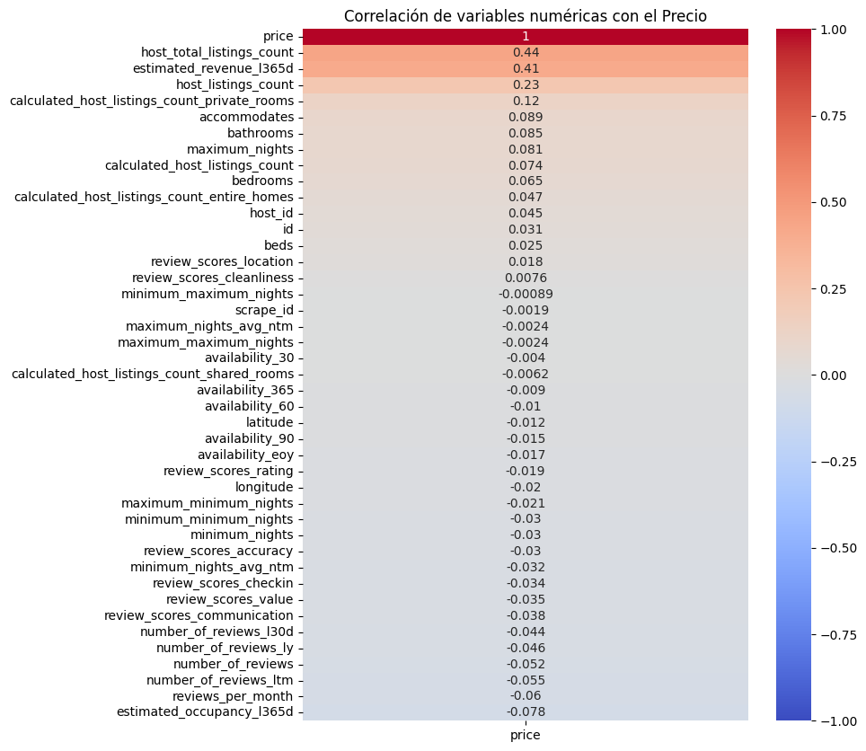

```python
##--- 3. ANÁLISIS DE RELACIONES (Con la variable respuesta: precio) ---
# Extraer numéricas y quitar NAs temporalmente para la matriz
num_vars = df.select_dtypes(include=['float64', 'int64', 'float32', 'int32']).dropna()

plt.figure(figsize=(8, 10))
# Enfocarnos solo en qué afecta al precio
correlacion_precio = num_vars.corr()[['price']].sort_values(by='price', ascending=False)
sns.heatmap(correlacion_precio, annot=True, cmap='coolwarm', vmin=-1, vmax=1)
plt.title('Correlación de variables numéricas con el Precio')
plt.show()
```

```python
from sklearn.cluster import KMeans
from sklearn.preprocessing import StandardScaler

# --- 4. ANÁLISIS DE GRUPOS (Clustering K-Means) ---
# 1. Escalar los datos
scaler = StandardScaler()
datos_escalados = scaler.fit_transform(num_vars)

# 2. Agrupamos en 3 perfiles
kmeans = KMeans(n_clusters=3, random_state=42)
num_vars['cluster'] = kmeans.fit_predict(datos_escalados)

# 3. Mostrar características promedio de los grupos
print("\n--- Características promedio por Grupo (Cluster) ---")
promedios_grupos = num_vars.groupby('cluster').mean()

# Imprimir solo algunas columnas clave para que sea fácil de interpretar
columnas_clave = [col for col in ['price', 'accommodates', 'bedrooms', 'bathrooms', 'review_scores_rating'] if col in num_vars.columns]
print(promedios_grupos[columnas_clave])
```

```
--- Características promedio por Grupo (Cluster) ---
               price  accommodates  bedrooms  bathrooms  review_scores_rating
cluster
0        1375.386946      4.805102  1.636364   1.677415              4.441865
1         221.949439      4.206859   1.53994   1.392062              4.874350
2         346.331199      5.506588  2.115174   1.781847              4.837105
```

```python
# --- PASOS 4 y 6: DIVISIÓN DE DATOS Y FEATURE ENGINEERING ---
from sklearn.model_selection import train_test_split

# Definir variables predictoras (X) y variable objetivo (y)
# Excluímos 'price' porque es lo que queremos predecir, y 'cluster' porque es un resultado del paso anterior
X = num_vars.drop(columns=['price', 'cluster'])
y = num_vars['price']

# Dividimos los datos: 80% para entrenamiento y 20% para prueba.
# random_state=42 garantiza que la división sea reproducible.
X_train, X_test, y_train, y_test = train_test_split(X, y, test_size=0.2, random_state=42)

print(f"Tamaño del conjunto de entrenamiento: {X_train.shape[0]} filas")
print(f"Tamaño del conjunto de prueba: {X_test.shape[0]} filas")
```

```
Tamaño del conjunto de entrenamiento: 49976 filas
Tamaño del conjunto de prueba: 12495 filas
```

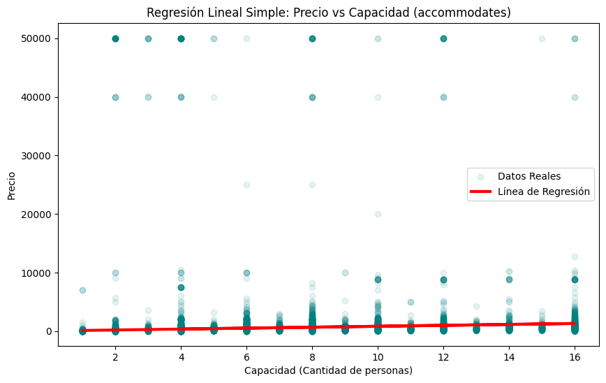

```
Resumen Modelo Simple (Entrenamiento):
R^2: 0.0084
RMSE: 2545.2255
```

```python
# --- PASO 7: MODELO DE REGRESIÓN LINEAL SIMPLE (Univariado) ---
from sklearn.linear_model import LinearRegression
from sklearn.metrics import mean_squared_error, r2_score
import matplotlib.pyplot as plt

# Elegimos 'accommodates' (capacidad) por ser una de las que suele tener mayor correlación con el precio
X_train_simple = X_train[['accommodates']]
X_test_simple = X_test[['accommodates']]

# Crear y entrenar el modelo
modelo_simple = LinearRegression()
modelo_simple.fit(X_train_simple, y_train)

# Hacer predicciones sobre el set de entrenamiento
predicciones_simple = modelo_simple.predict(X_train_simple)

# Graficar el modelo univariado
plt.figure(figsize=(10, 6))
plt.scatter(X_train_simple, y_train, color='teal', alpha=0.1, label='Datos Reales')
plt.plot(X_train_simple, predicciones_simple, color='red', linewidth=3, label='Línea de Regresión')
plt.title('Regresión Lineal Simple: Precio vs Capacidad (accommodates)')
plt.xlabel('Capacidad (Cantidad de personas)')
plt.ylabel('Precio')
plt.legend()
plt.show()

print("Resumen Modelo Simple (Entrenamiento):")
print(f"R^2: {r2_score(y_train, predicciones_simple):.4f}")
print(f"RMSE: {mean_squared_error(y_train, predicciones_simple) ** 0.5:.4f}")
```